# iNaturalist推廣活動–屁孩常見植物

CTH

2018-10-19

TOP

# 鳩竟未來國家棟樑很會的植物是？

蒙第58屆中小學科學展覽會邀請，小魯有幸協助推廣國立嘉義大學和特有生物研究保育中心大力支持的**iNaturalist**生物影音平台，在現場招架各種形狀 (?) 的屁孩，抄襲隔壁ebird攤位發想出個題目，讓屁孩們有事做。  
題目是這樣的：**請說出一個植物名稱**，在屁孩放電後期加入獎勵機制，若是現場第一次講到的植物可得小獎品，目的是增加一些潛在常見植物，也加速發送好重不想背回去的小獎品的效率。  
結果如何，就讓我們繼續看下去。

資料在這邊請笑納 -> [我是資料](https://drive.google.com/open?id=1qVfn7v4TgSTIF0eNJ_b_bmkYnEvmcJqc)

## 資料前處理

一共問啊問的，共收集到好棒棒的377筆資料，一些俗名稍微轉換一下，方便後續統計，例如大花咸豐草就出現大花咸豐草、咸豐草、鬼針草、恰查某各種同物異名的狀況，必須統一，其他還有一些資料輸入時的打字錯誤等等。

## 資料統計

### 載入套件

```r
library(magrittr)
library(tidyverse)
library(readxl)
library(showtext)
```

### 載入資料

資料已在excel中小計好了，直接匯入統計表。

```r
dat <- read_xlsx("d:/iNaturalist/201807exhibition/iNatEXB_plantlist.xlsx",
                 sheet = "output",
                 col_names = TRUE)
```

### 物種數、排名

首先先不分類，僅依照次數由多到少排序，在記錄到的165種植物中，前五名依序為玫瑰花 (8%)、大花咸豐草 (5%)、榕樹 (5%)、向日葵 (4%)和仙人掌 (3%)。

```r
dim(dat)[1] %>% cat("共紀錄",. ,"物種 \n")
```

```
## 共紀錄 165 物種
```

```r
sp.dat <- dat %>% arrange(desc(count)) %>% select(vname,count)
sp.dat
```

| vname | count |
| --- | --- |
| 玫瑰花 | 30 |
| 大花咸豐草 | 18 |
| 榕樹 | 17 |
| 向日葵 | 14 |
| 仙人掌 | 13 |
| 含羞草 | 12 |
| 蒲公英 | 8 |
| 薰衣草 | 8 |
| 九層塔 | 7 |
| 百合 | 7 |

[output cut: 155 more lines]

### 繪製長條圖

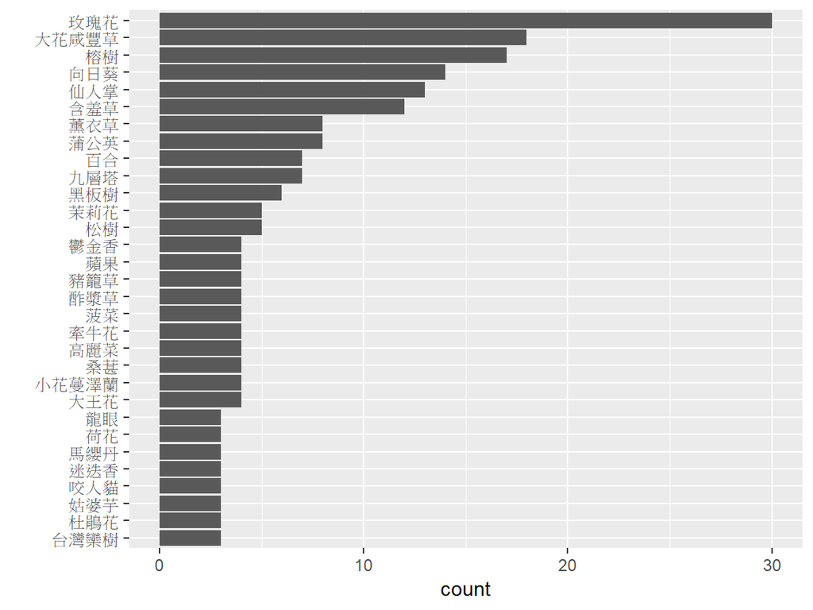

```r
font_add("msjh","msjh.ttc")
showtext_auto(TRUE)
p <- ggplot(data = dat %>% filter(count >= 3),
            mapping = aes(x = reorder(vname,count),y = count)) +
  geom_col() +
  coord_flip() +
  labs(x = "") +
  theme(text = element_text(family = "msjh"))
showtext_auto(FALSE)
p
```

## —— 以下開始寫正文好了 ——

# 生物多樣性之研究者的猜想與大眾落差－菜是植物嗎？

## Do you see the people see on plant biodiversity, researchers?

- 許正德Cheng-Te Hsu<sup>1</sup>、林大利Da-Li Lin<sup>2</sup>、陳宛均 Wan-Jyun Chen<sup>2</sup>
- 特有生物研究保育中心棲地生態組研究助理<sup>1</sup>、助理研究員<sup>2</sup>

## 前言

承接前一期【生物多樣性主流化調查–雞不是鳥???】探討大眾心中鳥類多樣性的猜想，實際調查之後發覺餐桌上的雞竟然普遍不被認為是鳥，可見研究者心中鳥的形象和大眾的想像是有落差的，因此作者好奇對於同樣是餐桌上常見的「可食植物」－蔬菜、水果在常人眼中可能是什麼樣子呢？會不會有類似的「我不了解你的明白」情況發生呢？ 本中心蒙國立中興大學舉辦的「中華民國第58 屆全國中小學科學展覽會」之邀，於會場設置eBird Taiwan與iNaturalist攤位推廣兩個生物多樣性網路平台，同時直球對決會場的未來主人翁，向國中小學生發問：「第一個想到的植物是什麼？」

## 問題猜想

「見面三分情」，表達出第一印象的重要，每個人心中都有一把尺，每天對每個事物評量好壞，並調整在心中的順位，通常脫口而出的第一印象都帶有特殊的含意的，第一個想到的植物可能是最喜歡的花朵、最愛吃的食物、最印象深刻的氣味等等，是關乎個人對於生活周遭被動接觸或主動發覺的過程，因此我們的命題希望能引導出我們所知的植物多樣性是來自餐桌？校園？還是野外？或甚至是虛擬的遊戲世界呢？

## 心目中No.1植物

從國中小師生家長應答取得377筆資料(圖1)，共紀錄到了165種植物，前五名依序為玫瑰花 (8%)、大花咸豐草 (5%)、榕樹 (5%)、向日葵 (4%)和仙人掌 (3%)，其他還包括含羞草、薰衣草、蒲公英、百合、九層塔、黑板樹、茉莉花、松樹等等。

## 萬萬想不到－什麼是植物？

還沒聽到答案之前，就先被反問反問：「花是植物嗎？」、「草是植物嗎？」、「樹是植物嗎？」、「菜是植物嗎？」，這類的問題顯示一個訊息：其實大眾不確定「植物」的定義，由此作者便依循這些大眾主觀認定的類群（表1），對應其可能的植物形態特徵描述，以利物種依照定義歸類，並依此統計所佔的比例。

## 蔬果天天吃，怎麼都沒記得？

整體而言，每天都吃得蔬果、飲料、辛香料類所佔比例是最少的，探討植物性食物較少被提及的可能原因，一方面是可能供選擇食材的多樣性不高，或者沒有嘗試記得食材的名稱，並且在經過烹煮之後，原先的植物器官形象與活體狀態差異過大，較難聯想植物活體的樣子。另一方面，菜販或家庭成員沒有說明食材名稱或展示食材的原貌，甚至會不清楚吃的究竟是什麼，以致食材多樣性的訊息未能完整的傳播。而由「花」和「草」及「樹木」統計數量的差異而言，可大致反映人類五官感覺中，視覺所扮演的主要接收訊息角色，因此在開花為主體的植物較容易觀察到而印入腦海之中，使得相較其他的分類來說，「花」成為對於植物的第一印象。

## 從餐桌到戶外的植物多樣性教育

飲食植物較少被提及，甚至不及非飲食植物的一半，這樣的差異延伸出兩個軸線討論： 其一為廚房、餐桌為植物多樣性教育的重要場域，需要加強認識餐桌上的多樣性，可透過親子互動，共同了解食材的一生，由蔬果的名稱和形態認識起，透過五官感覺，吃出植物多樣性的故事，進而提出疑問：蔬果哪裡來？怎麼長出來的？拐瓜劣棗能吃嗎？怎麼造成的呢？咖啡品種百百款，到底是在多什麼？關於上述十萬個為什麼的一隅，皆可在親子互動或教案演練之中蒐集資料，藉由圖說或現場體驗活動找到答案，並且在過程中自然習得，進而從中擴展，提出新的問題，拓展知識領域。

其二是除了能吃能喝的植物之外，還有什麼植物呢？植物同時提供人類木材、纖維、能源、醫藥、娛樂以及發揮生態功能，這些在食、衣、住、行之中有關的植物是誰呢？在吃飽喝足之餘，不妨暫時離開餐桌，走出戶外找找吧！公園綠地、郊山、深山之中，可利用各地區的特色和解說資源了解植物多樣性，如植物園、博物館系統：台北植物園、國立自然科學博物館植物園、凹仔底原生植物園等等，藉由解說牌自主學習或解說教育活動寓教於樂。或者前往郊山系統、深山野嶺進階探尋，不妨用手機、錄音機記錄下所見所聞，透過興趣團體、線上社群平台，如自然攝影中心、臉書社團、iNaturalist生物影資料庫平台等等聯絡管道快速分享，及時回覆討論，有助於個人自主學習及自由探索發布自然一草一木。

其中推薦iNaturalist平台，環境教育活動設計者可在平台中設計開發專案活動，進行物候監測、校園植物圖鑑等等的課程設計或科展專題，讓學習者成為教育現場的主體，不再是講授關係，透過分享、討論、競賽的方式，引導學習動機以使得學習植物不再是「界、門、綱、目、科、屬、種」的階層式架構，而是網狀的串聯物種名稱和一連串的問句，如「花生長在樹上嗎？」、「香蕉是樹還是大草？」、「吃蘋果都沒吃到果肉？」、「高麗菜好吃、花椰菜恐怖，可是他們卻是同一種植物？」、「他說的柿子怎麼是我說的番茄？」、「冰淇淋的香草風味是從木材中提煉出來的？」、「一棵樹的一生跟我有什麼關係呢？」，等等的吃、喝植物學小知識，所建立的觀察記錄進而傳送至全球生物多樣性資訊機構（Global Biodiversity Information Facility, GBIF），應用在生物多樣性的不同地理尺度的物種監測、研究分析之中，不僅是分享學習，更有助於國內、區域、世界、跨領域的整合應用，如環境變遷、生物多樣性指標、保育政策擬定。

## 結語

記得筆者小時候一個電視節目的歌詞：「大自然真奇妙，就看你有沒有注意到」，在繁忙而快速的水泥叢林裡，我們希望我們島嶼上的人們和世界上的人類社會能夠永續，真正成為地球環境的一份子，期望每個人心中埋藏一顆生物多樣性的主流價值的種子，首要的目標便是從認得手上咬了一口的蘋果開始，培養在任何時刻、任何牆角、草地、森林、河海之中都能發覺自然間互動和生命的密碼，使得人類融入生態系，永續綿長生存。

##### 表1、植物形態特徵描述定義

| 分類 | 定義 |
| --- | --- |
| 花 | 賞花植物:花顯眼為主要特徵，開花時可輕易被發現，或個體小但花明顯 |
| 草 | 花小不明顯，無樹幹特徵，通常感覺不能吃 |
| 草本植物 |  |
| 樹木 | 有樹幹特徵，一般高大超過常人的身高 |
| 木本植物 |  |
| 食物 | 蔬菜、水果、飲料、辛香料 |
| 原生 | 自然分布下出現的物種 |
| 外來物種 | 人為干預而出現於非原生地的物種 |
| 外來馴化物種 | 與人長久選汰之作物 |

##### 圖1、物種累計長條圖

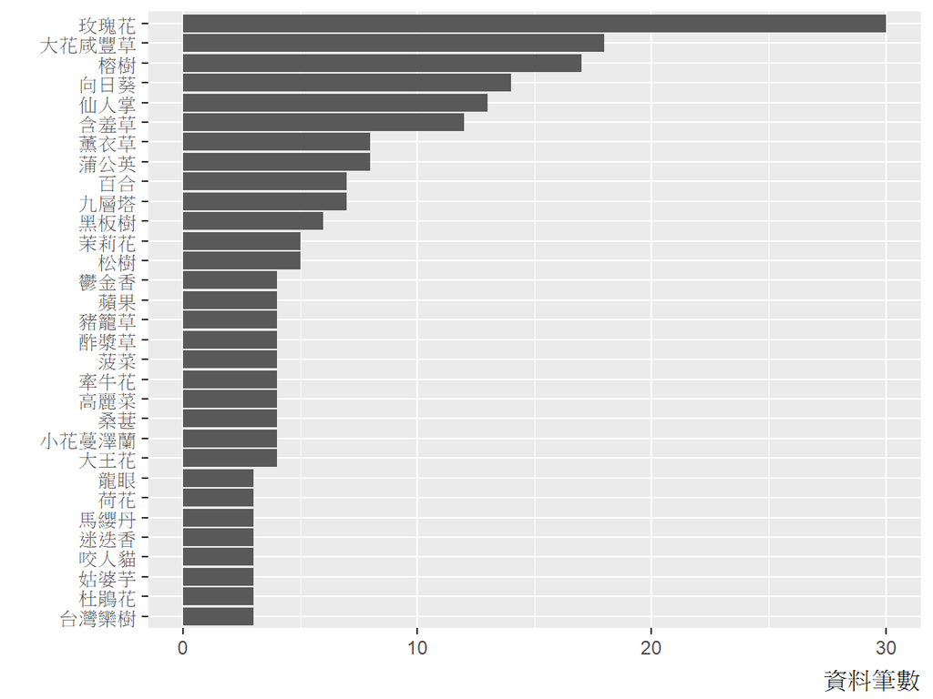

##### 圖2、植物依形態特徵分類統計直方圖

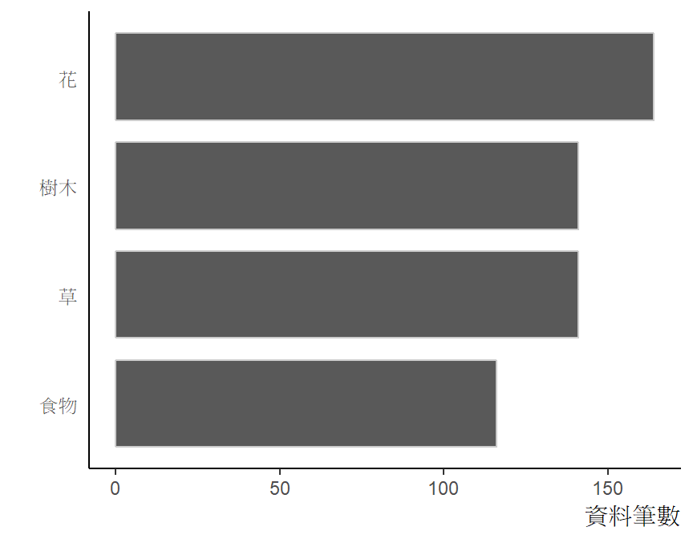

## —— 以下還不知道能幹啥 ——

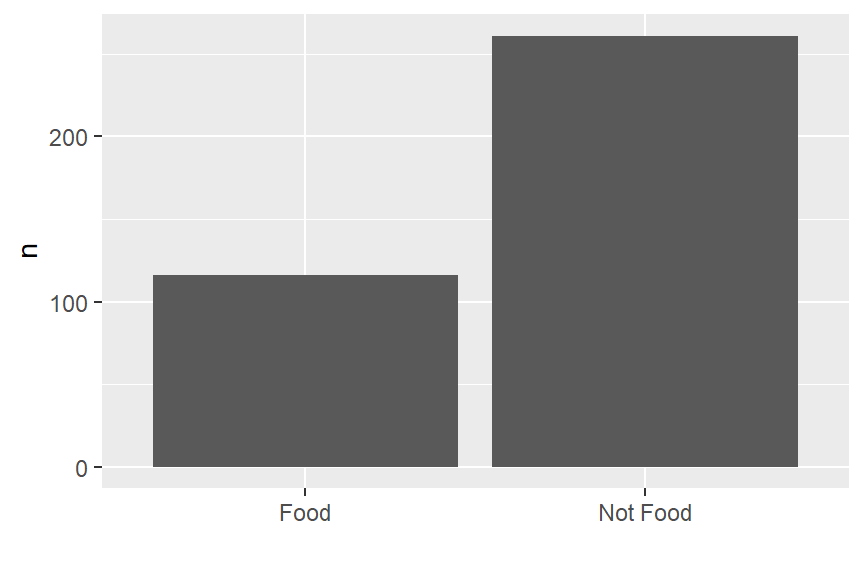

```r
food.dat <- tibble(
  `Food` = dat %>% filter(isFood == 1) %>% pull(count) %>% sum(),
  `Not Food` = dat %>% filter(isFood != 1) %>% pull(count) %>% sum()
) %>% gather(data = .,key = "group",value = "n")
p <- ggplot(data = food.dat,mapping = aes(x = group,y = n)) +
  geom_col() +
  labs(x = "")
p
```

## 原生種 V.S. 外來種

所調查到物種之中，原生種的比例僅佔23%，約七成的常見物種屬於外來種。

```r
n.total <- dat %>% pull(vname) %>% unique() %>% length()
n.native <- dat %>% filter(isNative == 1) %>% pull(vname) %>% unique() %>% length()
(n.native/n.total*100) %>% round(., digits = 1) %>% paste0(.,"%")
```

```
## [1] "23%"
```

```r
dat %>% filter(isNative == 1) %>% pull(vname)
```

```
##  [1] "七里香"     "水筆仔"     "水黃皮"     "台灣萍蓬草" "台灣欒樹"
##  [6] "光臘樹"     "艾草"       "芒草"       "車前草"     "姑婆芋"
## [11] "拖鞋蘭"     "松樹"       "爬牆虎"     "狗尾草"     "南湖柳葉菜"
## [16] "咬人狗"     "咬人貓"     "扁柏"       "紅檜"       "苦楝"
## [21] "桑葚"       "浮萍"       "海草"       "海檬果"     "常春藤"
## [26] "構樹"       "筆筒樹"     "腎蕨"       "酢漿草"     "楓樹"
## [31] "榕樹"       "樟樹"       "薄雪草"     "麵包樹"     "櫻花"
## [36] "蘭花"       "鐵杉"       "魔芋"
```

## 這些植物能吃

```r
n.food <- dat %>% filter(isFood == 1) %>% pull(vname) %>% length()
(n.food/n.total*100) %>% round(., digits = 1) %>% paste0(.,"%")
```

```
## [1] "33.3%"
```

```r
dat %>% filter(isFood == 1) %>% pull(vname)
```

```
##  [1] "九層塔" "人蔘"   "小白菜" "山楂"   "水蜜桃" "水稻"   "火龍果"
##  [8] "仙人掌" "向日葵" "地瓜葉" "西瓜"   "咖啡樹" "枇杷"   "波羅蜜"
## [15] "空心菜" "花椰菜" "芹菜"   "青江菜" "哈密瓜" "枸杞"   "秋葵"
## [22] "紅毛丹" "紅棗"   "胡瓜"   "韭菜"   "香蕉"   "桑葚"   "茶樹"
## [29] "草莓"   "荔枝"   "迷迭香" "馬鈴薯" "高麗菜" "梅花"   "荷花"
## [36] "構樹"   "紫蘇"   "菊花"   "菠菜"   "菱角"   "黑棗"   "椰子樹"
## [43] "葡萄"   "綠豆"   "蝶豆花" "橘子"   "龍眼"   "薄荷"   "羅勒"
## [50] "羅漢果" "蘆薈"   "蘋果"   "蘋婆"   "麵包樹" "櫻桃"
```

## 這些植物又宅原生又能吃

```r
dat %>% filter(isFood == 1 & isNative == 1) %>% pull(vname)
```

```
## [1] "桑葚"   "構樹"   "麵包樹"
```